# Lecture 12: Introduction to Age Models

1. The importance of knowing time
2. Building an age model
   - Markov chain Monte Carlo approaches
   - constant sedimentation rates
   - varying sedimentation rates

*We acknowledge and respect the lək̓ʷəŋən peoples on whose traditional territory the university stands and the Songhees, Esquimalt and W̱SÁNEĆ peoples whose historical relationships with the land continue to this day.*

# Importance of knowing time

[figure not shown]

# Importance of knowing time

[figure not shown]

# Age models are important: how do we get them?

1. Cyclostratigraphy
2. Biostratigraphy
3. Absolute ages
   - U-Pb (volcanics), Ar-Ar (volcanics), Re-Os (sediments)
4. Signal matching
   - magnetostratigraphy
   - chemostratigraphy
5. Relative ages
   - Amino Acid Racemization

# Biostratigraphy

- based on the unique, sequential, nonrepeating appearance of fossils through time

[figure not shown]

# Biostratigraphy

- based on the unique, sequential, nonrepeating appearance of fossils through time
- observations are: first appearance and last appearance per section

[figure not shown]

- what is wrong with this picture?
- fence diagram (correlation) of the observed FADs and LAD between 7 sections that preserve 62 taxa of the Cambrian Riley Formation of Texas (data from Palmer, 1954; Shaw, 1964).
- lines are meant to represent time lines, so equal time

[figure not shown]

# Contradictory ranges

- what could be causing this?

[figure not shown]

# Contradictory ranges

[figure not shown]

# Resolving contradictory ranges

- ranges of original data need modifcation to be consistent everywhere (time goes left to right)

[figure not shown]

# Resolving contradictory ranges

- can we rule any out? working out the possibilities not so hard with just two taxa..

[figure not shown]

# Resolving contradictory ranges

- can we rule any out? working out the possibilities not so hard with just two taxa.. 90 options with 3,

[figure not shown]

- in actuality, there are 6 different possibilities that could be considered
- time is older on the left, and younger on the right
- we can rule out some of these, because we have direct evidence of coexistence
- this is pretty tractable, and we could pretty quickly come up with a solution
  - a guiding principle is, do the MINIMUM amount of modification needed to make the ranges consistent
- OK, but what if we are dealing with THREE TAXA
  - number of possibilities grows to 90

# Number of possible sequences

- requires constrained optimization (CONOP9; Sadler and Cooper, 2008)
- number of atoms in universe = $10^{82}$

[figure not shown]

# Best-fit solution

- what are some features of this that look familiar to our model outputs?

[figure not shown]

# Building an age model

# Building an age model

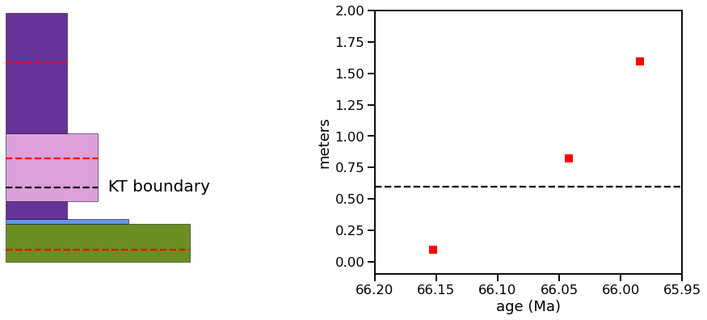

```python
fig=plt.figure(1,figsize=(15,6))
ax=fig.add_subplot(121)
ax,trace,boxes,liths=rando_strat(ax,num_box=5,height=2,boxes=[],liths=[]) #stratigraphy for fun
#ashes in the strat column
for a in ashes:
    tmp_w=trace[(trace[:,0]<=ashes[a]['height']) & (trace[:,1]>ashes[a]['height']),2]
    ax.plot([0,tmp_w],[ashes[a]['height'],ashes[a]['height']],'r--')
#KT boundary
tmp_w=trace[(trace[:,0]<=KT) & (trace[:,1]>KT),2]
ax.plot([0,tmp_w],[KT,KT],'k--')
ax.text(tmp_w,KT,'  KT boundary',verticalalignment='center',fontsize=20)
#ash ages
ax=fig.add_subplot(122)
for a in ashes:
    ax.plot(ashes[a]['age'],ashes[a]['height'],'rs')
ax.plot([66.2,65.95],[KT,KT],'k--')
ax.set_xlim([66.2,65.95]); ax.set_ylim([-0.1,2])
ax.set_ylabel('meters'); _=ax.set_xlabel('age (Ma)')
```